# Module 6. Interpretation, contrasts and prediction

Workbook

```r
source(here::here("R", "setup.R"))
walk <- load_walk()
```

**WarningSimulated data**

All examples use simulated data from fictional studies. Results illustrate methods; they are not empirical findings.

These exercises turn the primary WALK model into results: reading coefficients, computing estimated marginal means (EMMs) and planned contrasts, handling multiplicity, making predictions with the right kind of interval, and presenting it all clearly. Chunks with blanks (`___`) are set to `eval: false`; fill in the blanks and run them.

```r
sched <- c(0, 1, 3, 6, 9, 12)
m_prim <- lmer(sbp ~ visit_f * arm + (1 + month | id), data = walk, control = lmer_ctrl)
```

## 1 Guided exercises

### 1.1 Exercise 1. Coefficients, interactions and centring (LO 6.1)

1. Fit the linear-time model with time centred at month 6.

```r
walk$month6 <- walk$month - ___
m_lin6 <- lmer(sbp ~ month6 * arm + (1 + ___ | id), data = walk, control = lmer_ctrl)
fixef(m_lin6)
```

2. Before looking at the output, use the uncentred estimates ($\hat\beta_2 = 0.31$ for `armSP`, $\hat\beta_4 = -0.49$ for `month:armSP`) to predict the new `armSP` coefficient. Then check.
3. In the primary model, find the coefficient that equals the difference in mean change from baseline to month 6 for EP versus UC.

**Questions.** (i) What does `armSP` mean in `m_lin6`? (ii) Which coefficients are the same in the centred and uncentred models? (iii) What does `visit_f6` mean in the primary model?

### 1.2 Exercise 2. Estimated marginal means (LO 6.2)

1. Compute the EMMs for every arm and visit and convert them to a data frame.

```r
emm <- emmeans(m_prim, ~ ___ * ___)
emm_tab <- as.data.frame(summary(emm))
```

2. Compute the observed mean SBP of attended visits for every arm and visit, and join them to `emm_tab`.

**Questions.** (i) At which visit do EMMs and observed means agree, and why? (ii) In which direction do they differ at month 12, and what feature of the WALK study explains it?

### 1.3 Exercise 3. Planned contrasts (LO 6.2)

1. Build coefficient vectors for the difference in mean change from baseline to month 6, SP versus UC and EP versus UC.

```r
cells  <- expand.grid(visit_f = levels(walk$visit_f), arm = levels(walk$arm))
cell_w <- function(a, v) as.numeric(cells$arm == a & cells$visit_f == v)
chg6   <- function(a) cell_w(a, "___") - cell_w(a, "0")
L6 <- list("SP - UC" = chg6("SP") - chg6(___),
           "EP - UC" = chg6(___) - chg6("UC"))
sapply(L6, sum)                          # should be 0
summary(contrast(emm, L6), infer = TRUE)
```

2. Obtain the same estimates with the interaction-contrast approach.

```r
contrast(emm, interaction = c(visit_f = "___", arm = "___"))
```

**Questions.** (i) Report the two month-6 differences in a sentence each. (ii) Why is the SE of a within-arm change smaller than the SE of either EMM?

### 1.4 Exercise 4. Population-average and subject-specific predictions (LO 6.4)

1. Add both kinds of prediction to the data.

```r
walk$pred_pa <- predict(m_prim, re.form = ___)
walk$pred_ss <- predict(m_prim)
```

2. Build a complete grid (every participant at every scheduled month, with `month` equal to the scheduled month), predict both ways, and compare the averages by arm and visit.
3. Compare the averages over the **observed** rows at month 12.

**Questions.** (i) Why do the averages agree on the complete grid? (ii) Why do they disagree on the observed rows? (iii) Which should be used to estimate a treatment effect?

### 1.5 Exercise 5. Confidence and prediction intervals (LO 6.5)

1. For the standard programme at every visit, compute the 95% prediction interval for a single measurement of a new participant.

```r
G  <- as.matrix(VarCorr(m_prim)$id)
s2 <- sigma(m_prim)^2
pi_sp <- as.data.frame(summary(emm)) |>
  filter(arm == "SP") |>
  mutate(month = as.numeric(as.character(visit_f)),
         var_between = G[1, 1] + 2 * G[1, 2] * ___ + G[2, 2] * ___^2,
         se_new = sqrt(SE^2 + var_between + ___),
         pi_lower = emmean - 1.96 * se_new, pi_upper = emmean + 1.96 * se_new)
```

2. Check the month-12 interval by simulation (draw $\boldsymbol\beta$, $\mathbf{b}$ and $\varepsilon$).
3. Plot the CI and PI for SP on the same axes.

**Questions.** (i) How many times wider is the PI than the CI at month 12? (ii) Which variance component contributes most to the PI? (iii) Which interval would you give to a clinician asking about one patient?

## 2 Independent exercises

### 2.1 Exercise 6. Report the month-6 results (LO 6.2, 6.6)

Produce a results table for the change from baseline to month 6 (within-arm changes, differences versus usual care with 95% CIs and p-values), and write a two-sentence results paragraph.

### 2.2 Exercise 7. Compare multiplicity strategies (LO 6.3)

For the three month-12 comparisons (SP − UC, EP − UC, EP − SP), compare: no adjustment, Holm across all three, Tukey (`pairwise` contrasts of the month-12 changes), and a fixed sequence EP − UC, then SP − UC, then EP − SP. Which comparisons are significant under each, and which strategy would you prespecify? Justify in a short paragraph.

### 2.3 Exercise 8. Predictions for individual participants (LO 6.4, 6.5)

Choose one usual-care participant with all six visits and one who dropped out after month 3. For each, compute the subject-specific prediction at month 12 with a 95% prediction interval (use `ranef(m_prim, condVar = TRUE)`), and plot their observed data with their predicted trajectory and the population-average trajectory. Explain why the two intervals differ in width.

### 2.4 Exercise 9. Repair a misleading figure (LO 6.6)

The code below produces a misleading figure. List at least four problems and produce an improved version.

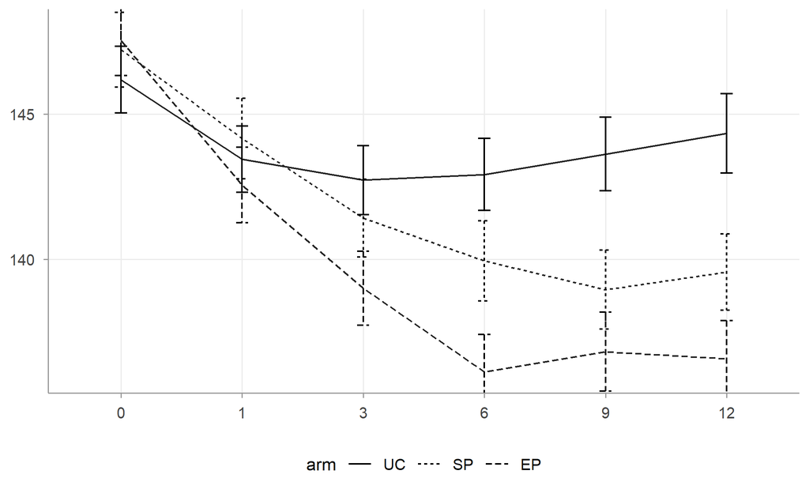

A figure with several problems.

```r
walk |>
  group_by(arm, visit_f) |>
  summarise(m = mean(sbp), se = sd(sbp) / sqrt(n())) |>
  ggplot(aes(visit_f, m, group = arm, linetype = arm)) +
  geom_line() +
  geom_errorbar(aes(ymin = m - se, ymax = m + se), width = 0.1) +
  coord_cartesian(ylim = c(136, 148)) +
  labs(x = NULL, y = NULL)
```